# QuREBB: Quantum Remote Entanglement Building Block Simulations

Welcome to the **QuREBB**! Here, we introduce a modular theoretical framework designed for the comprehensive understanding and comparison of various photon-mediated remote entanglement protocols (REPs). This notebook is based on the framework and results outlined in our tutorial paper ["Tutorial: Remote entanglement protocols for stationary qubits with photonic interface"](https://arxiv.org/abs/2310.19878v1). Structured into four distinct layers, this framework facilitates the assembly of modules by connecting one's output to another's input, elucidating the intricate mechanisms underpinning entanglement.

The primary strength of our framework is its capability to delineate common features inherent to different remote entanglement protocols. Beyond this, it is designed with adaptability at its core, enabling users to modify modules with precision. This adaptability is crucial to compare a protocol across diverse quantum hardware setups or to test an array of protocols on a consistent hardware foundation. Such modularity and precision often remain elusive in dedicated entanglement simulations tailored for specific experimental setups. Dive deep into the intricacies of photon-mediated entanglement generation between qubit systems, and leverage the robust capabilities of our simulation suite.

## Photon-mediated Remote Entanglement Protocols

Photon-mediated remote entanglement protocols are essential in quantum networks, quantum computing, and quantum communication, with the synthesis of quantum mechanics and photonic technology. These protocols enable the generation of quantum entanglement between stationary qubits (often called "quantum memory") over long distances. At the core of these protocols is the utilization of photons as intermediaries, leveraging their inherent stabilities over optical fibers. This approach not only circumvents the limitations posed by the direct interaction of qubits but also harnesses the speed and coherence properties of photons, making long-range quantum communication feasible.

The significance of these protocols lies in their potential to create extensive quantum networks, similar to the internet, but operating on the principles of quantum mechanics. Such networks could revolutionize data security through quantum cryptography and enable distributed quantum computing, where computational tasks are shared across multiple quantum nodes. The development of photon-mediated remote entanglement protocols is thus a critical step towards realizing the full potential of quantum technologies. It merges the realms of quantum photonics, where light-matter interactions are manipulated at the quantum level, with quantum information science, offering innovative solutions to the challenges of scalability and robustness in quantum systems.

Figure 1(a) shows photon-mediated remote entanglement protocols with three different topologies---detection-in-midpoint (ingoing), sender-receiver, and source-in-midpoint (outgoing).

In the detection-in-midpoint topology, both endpoints generate spin-photon entanglement. The photons are then measured in the middle, in an entangled basis using a Bell state measurement. This projects the two spins in an entangled state. The detection-in-midpoint topology has an advantage in its simplicity. At its most basic, this topology requires only photon-emission from the spins, beamsplitter interference of the photons, and single-photon detections at the central station. Efficient spin-photon interfaces like optical cavities, while helpful, are not necessary to get high-fidelity entanglement. Furthermore, the time overhead for classical communication is reduced by half compared to the other topologies, since the endpoints communicate solely with the detection point, eliminating the need for direct communication between them.

In the sender-receiver topology, the first endpoint generates spin-photon entanglement, and the photon is then sent to the second endpoint, where it interacts with the spin, such that entanglement between the spins is achieved. This interaction can be a gate-like behavior (e.g. by using an optical cavity) after which the photon is measured. Alternatively, the photon can be absorbed by the spin-photon interface in which case this topology matches the workings of quantum state transfer [2, 3]. The sender-receiver topology does not necessitate an intermediary station for the spins to become entangled. However, the classical communication time for the heralding signal is twice as long compared to a detection-in-midpoint, as it needs to travel the full distance as opposed to half of it.

The source-in-midpoint topology has an entangled photon source in the middle which sends these photons to the endpoints. The endpoints have an entangling interaction between the spin and the photon, after which the photons are measured and the spins will be projected into an entangled state. The source-in-midpoint topology is useful in satellite-assisted entanglement protocols. Ground-to-satellite channel (uplink) has a higher overall loss than the satellite-to-ground channel (downlink). Phenomenologically, this phenomenon is collectively referred to as the “shower curtain effect” of the atmosphere. In particular, the diffraction and deflection by air turbulence are more severe in the early stage of transmission than in the late stage on the dispersed beam. Moreover, practical factors such as limited onboard optics on the satellite result in a larger pointing error in the uplink than the downlink.

Remote entanglement between two stationary qubits has been experimentally realized with sender-receiver topology using trapped atoms embedded in optical cavities, and with detection-in-midpoint using several platforms including NV centers in diamond, quantum dots, trapped ions, and neutral atoms.

[figure not shown]

**Figure 1** - Overview of remote entanglement protocol modular framework. **Entanglement link** - The objective of entanglement protocols is to entangle two remote spins (purple) where the entanglement is created by photons (red). (a) **Logical Building Blocks (LBB)** and Topology - The topology for remote entanglement generation is deconstructed in logical building blocks (LBBs). From left to right, we consider three main REP topologies: the detection-in-midpoint, sender-receiver, and source-in-midpoint topology. (b) **Encoding** - The encoding layer chooses the basis for the photonic qubits and the levels for the spin qubit. We illustrate the time-bin encoding of sender-receiver topology with spin-photon gates. (c) **Physical Building Blocks (PBB)** - The physical building blocks (PBBs) are the quantum channel describing the operations of the physical systems including imperfections. This layer shows the REP at the physical level. The first panel describes the construction of spin-photon gates with an overcoupled cavity QED system for state conditional amplitude reflection. The second panel shows the implementation of a measurement of the time-bin qubit in the X-basis, using a Mach-Zehnder interferometer. (d) **Quantum optical modeling** - This layer models the hardware used in the PBB. In this example the relevant parameters for the PBBs (e.g. state-dependent reflection coefficient, $r_{\ket{0}, \ket{1}}$) can be calculated from physical variables (e.g. spin-cavity coupling rate, $g$), using a detailed quantum optical model. We implemented these descriptions in a software package publicly available on GitHub.

## Setting up the protocol:

```python
# Utility and common imports

import sys
from os.path import expanduser, join
home = expanduser("~")
sys.path.append(join(home, 'Repositories/2024.CQNSCHOOL.DIGITALTWIN'))
from copy import copy
import numpy as np
import matplotlib.pyplot as plt

# QuREBB library imports

import lib.LBB as lbb
import lib.PBB as pbb
import lib.NQobj as nq
import lib.states as st
import lib.quantum_optical_modelling as qom
from lib.PBB import no_vacuum_projector
from lib.protocol import Protocol
```

First, we look at the Logical Buildind Blocks and Encoding.

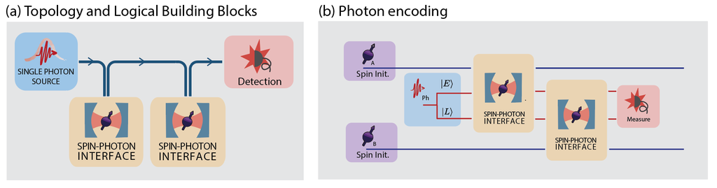

We start with a single photon in Time-Bin encoding, prepared in $|+\rangle = 1/\sqrt{2}(|E\rangle + |L\rangle)$, and two spins Alice and Bob, both prepared in $|+\rangle=1/\sqrt{2}(|\uparrow\rangle + |\downarrow\rangle)$.

The photon then interacts with a Conditional Amplitude Reflection SPI based on a cavity-emitter system of Alice, then with the one of Bob.

To measure entanglement we need to measure the photonic qubit in the X basis, therefore we apply a rotation gate before we measure in the| $\{|E\rangle, |L\rangle\}$ basis.

We first create our protocol, inheriting from the Protocol class. Here we need to define:

- The initial density matrix of the spin state(s)
- The projector of the photonic state we want to herald for successful entanglement
- The target state of our protocol

Often different final photonic states correspond to a different entangled state generation. The protocol allows one to define a list of photon state projectors and target states. They have to correspond one-to-one, for each herald state the protocol calculates the fidelity of the corresponding target state.

Detecting a photon in $|E\rangle$ will herald the final Bell state $|\psi_+\rangle$, and detecting a photon in $|L\rangle$ will herald $|\psi_-\rangle$. The detection is done using the projector on "non vacuum" state: $P = \mathbb{1} - |vac\rangle\langle vac |$.

```python
class ExampleProtocol(Protocol):
    """
        Our protocol class to simulate Spin-Photon Entanglement
    """
    def __init__(self, parameters: dict):
        super().__init__(parameters)

        # We prepare the initial state of the spins in |x >
        self.dm_init = nq.tensor(nq.name(st.x_dm, "Alice", "state"), nq.name(st.x_dm, "Bob", "state"))

        # We definet the two herald state projectors.
        self.herald_projectors = [
            no_vacuum_projector(name="E", dim=self.dim),
            no_vacuum_projector(name="L", dim=self.dim),
        ]

        # And the corresponding target entangled states

        state_uu = nq.tensor(nq.name(st.up, "Alice", "state"), nq.name(st.up, "Bob", "state"))
        state_dd = nq.tensor(nq.name(st.down, "Alice", "state"), nq.name(st.down, "Bob", "state"))

        self.target_states = [
            (state_uu + state_dd).unit(),
            (state_uu - state_dd).unit()
        ]
```

The Protocol class contains several built-in features, in particular:

- parameters: a dictionary of the parameters needed to run the protocol
- dm: the density matrix used for the evolution of the protocol
- fidelity, rate: values that get updated with the simulation results

A key function of Protocol is the *do_lbb()* function. This is a wrapper that applies a Logical Building Block to the density matrix, taking care to pass over all the relevant parameters. It is defined like this:

```python
    def do_lbb(self, LBB, **kwargs):
        """Makes a logical building block act on the density matrix."""
        kwargs.update(self.parameters)

        self.dm = LBB(dm_in=self.dm, **kwargs)
```

For example: let's start from the initial density matrix of our protocol, which contains only the spin states, and apply a photon source LBB to generate a photon in $|+\rangle = 1/\sqrt{2}(|E\rangle + |L\rangle)$.

This is how the source is defined in the LBB library:

```python
def photon_source_time_bin(dm_in, photon_early_name, photon_late_name, dim, alpha=None, **kw):
    # We can either create a single ephoton
    if alpha is None:
        photon_basis = st.photon(dim)

    # Or a coherent state
    else:
        photon_basis = qt.coherent(dim, alpha)

    #We create the photonic modes and we prepare them in the |+> state
    E = nq.name(photon_basis, photon_early_name, "state")
    L = nq.name(photon_basis, photon_late_name, "state")
    return nq.tensor(dm_in, nq.ket2dm((E + L).unit()))
```

```python
# We define the neccessary parameters to create the photon.
# "dim" is the Fock state dimension of each photonic Qubit state
parameters = {
    "dim": 2
}

p = ExampleProtocol(parameters)

#This is the initial density matrix, we use it to initialize the process density matrix p.dm
display(p.dm_init)
p.dm = p.dm_init

#Apply a photon source building block.
p.do_lbb(lbb.photon_source_time_bin, photon_early_name="E", photon_late_name="L")

# This is what the density matrix looks like after the LBB:
display(p.dm)
```

Quantum object: dims = [[2, 2], [2, 2]], shape = (4, 4), type = oper, isherm = True $ \\ \left(\begin{matrix}0.250 & 0.250 & 0.250 & 0.250\\0.250 & 0.250 & 0.250 & 0.250\\0.250 & 0.250 & 0.250 & 0.250\\0.250 & 0.250 & 0.250 & 0.250\\\end{matrix}\right)$ $\\$ names = [['Alice', 'Bob'], ['Alice', 'Bob']], kind = state

Quantum object: dims = [[2, 2, 2, 2], [2, 2, 2, 2]], shape = (16, 16), type = oper, isherm = True $ \\ \left(\begin{matrix}0.0 & 0.0 & 0.0 & 0.0 & 0.0 & \cdots & 0.0 & 0.0 & 0.0 & 0.0 & 0.0\\0.0 & 0.125 & 0.125 & 0.0 & 0.0 & \cdots & 0.0 & 0.0 & 0.125 & 0.125 & 0.0\\0.0 & 0.125 & 0.125 & 0.0 & 0.0 & \cdots & 0.0 & 0.0 & 0.125 & 0.125 & 0.0\\0.0 & 0.0 & 0.0 & 0.0 & 0.0 & \cdots & 0.0 & 0.0 & 0.0 & 0.0 & 0.0\\0.0 & 0.0 & 0.0 & 0.0 & 0.0 & \cdots & 0.0 & 0.0 & 0.0 & 0.0 & 0.0\\\vdots & \vdots & \vdots & \vdots & \vdots & \ddots & \vdots & \vdots & \vdots & \vdots & \vdots\\0.0 & 0.0 & 0.0 & 0.0 & 0.0 & \cdots & 0.0 & 0.0 & 0.0 & 0.0 & 0.0\\0.0 & 0.0 & 0.0 & 0.0 & 0.0 & \cdots & 0.0 & 0.0 & 0.0 & 0.0 & 0.0\\0.0 & 0.125 & 0.125 & 0.0 & 0.0 & \cdots & 0.0 & 0.0 & 0.125 & 0.125 & 0.0\\0.0 & 0.125 & 0.125 & 0.0 & 0.0 & \cdots & 0.0 & 0.0 & 0.125 & 0.125 & 0.0\\0.0 & 0.0 & 0.0 & 0.0 & 0.0 & \cdots & 0.0 & 0.0 & 0.0 & 0.0 & 0.0\\\end{matrix}\right)$ $\\$ names = [['Alice', 'Bob', 'E', 'L'], ['Alice', 'Bob', 'E', 'L']], kind = state

The *photon_source_time_bin()* function took care of creating the photons in the correct state and adding them to the density matrix, thanks to the tensor product using NQobj().

Now, in the same way we can apply the Conditional Amplitude Reflection SPI LBB.

In the ideal case, this is a spin-dependent cavity where the photon is totally reflected if the spin is in $|\downarrow\rangle$ and totally transmitted if the spin is in $|\uparrow\rangle$.

We first describe the LBB in terms of Physical Building Blocks:

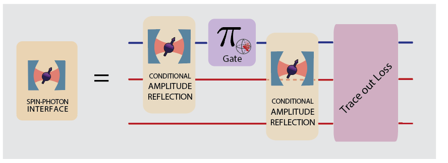

And we define the LBB function:

```python
def conditional_amplitude_reflection_time_bin_spi_ideal(
    dm_in,
    spin_name,
    photon_early_name,
    photon_late_name,
    dim,
    **kw,
):

    # Reflection coefficient and transmission coefficients for states up (u) and down (d)
    t_u = r_d = 1
    t_d = r_u = 0

    # No loss
    l_u = l_d = 0


    # We provide the parameters to the Physical Building Block of a conditional amplitude reflection SPI
    cav = pbb.conditional_amplitude_reflection(r_u, t_u, l_u, r_d, t_d, l_d, dim=dim)

    # Specifying which Spin it refers to.
    cav.rename("spin", spin_name)

    # We realise PBB implementation of the LBB, first the cavity is applied to Early
    cav.rename("R", photon_early_name)
    cav.rename("T", "loss_transmission")
    cav.rename("loss", "loss")

    dm_E_full = cav * dm_in * cav.dag()

    # Tracing out the lost modes
    dm_E = lbb.trace_out_loss_modes(dm_E_full)

    # We apply a pi rotation on the spin
    RX_pi = nq.NQobj([[0, 1], [1, 0]], names=spin_name, kind="oper")

    # And we apply the same cavity PBB to Late by renaming the photonic mode it operates on
    cav.rename(photon_early_name, photon_late_name)
    dm_L_full = cav * (RX_pi * dm_E * RX_pi.dag()) * cav.dag()

    #Finally we trace out the lost modes.
    dm_L = lbb.trace_out_loss_modes(dm_L_full)

    #Finally, we return the modified density matrix
    return dm_L
```

We can now apply this in our protocol, first to Alice:

```python
p.do_lbb(
        conditional_amplitude_reflection_time_bin_spi_ideal,
        photon_early_name="E",
        photon_late_name="L",
        spin_name="Alice",
)
```

Then to Bob:

```python
p.do_lbb(
        conditional_amplitude_reflection_time_bin_spi_ideal,
        photon_early_name="E",
        photon_late_name="L",
        spin_name="Bob",
)
```

Now we can herald and project the spins in an entangled state.

For this protocol to work, we need to measure the photons in the X basis. We can implement this by first rotating the basis and measuring in $\{|E\rangle, |L\rangle\}$.

```python
#First rotate the basis
p.do_lbb(lbb.basis_rotation, photon_names=["E", "L"])

#And herald on the photonic states we previously defined, to get the rate and fidelity:
def herald(dm_in, herald_projector, **kw):
    dm_final = herald_projector * dm_in * herald_projector.dag()
    return lbb.trace_out_everything_but_spins(dm_final)

#We herald on a photon in Early
heralded_dm_E = herald(copy(p.dm), p.herald_projectors[0])

# And check the fidelity and success probability of getting Psi_+
fidelity = nq.fidelity(heralded_dm_E.unit(), nq.ket2dm(p.target_states[0])) ** 2
rate = heralded_dm_E.tr()
print(f"Heralding a photon in Early gives the state psi_+ with Fidelity: {fidelity:.3f} and Success Probability: {rate:.3f} ")

#And we do the same with Late and Psi_-
heralded_dm_L = herald(copy(p.dm), p.herald_projectors[1])

fidelity = nq.fidelity(heralded_dm_L.unit(), nq.ket2dm(p.target_states[1])) ** 2
rate = heralded_dm_L.tr()
print(f"Heralding a photon in Late gives the state psi_- with Fidelity: {fidelity:.3f} and Success Probability: {rate:.3f} ")
```

```
Heralding a photon in Early gives the state psi_+ with Fidelity: 1.000 and Success Probability: 0.125
Heralding a photon in Late gives the state psi_- with Fidelity: 1.000 and Success Probability: 0.125
```

We have entanglement!

Now, the Protocol class contains several functions that make running the protocol much simpler. It will take care of initialising the density matrix, running all the LBBs and doing the hearlding and fidelity/rate measurement. This is done with the *Protocol.run()* function:

```python
    def run(self):
        """Runs the protocol sequence and return the metrics"""
        self.dm = self.dm_init
        self.protocol_sequence()
        fidelity, rate = self.herald()
        return fidelity, rate
```

So in our protocol, we can just define the *protocol_sequence()*

```python
class ExampleProtocol(Protocol):
    """
        Our protocol class to simulate Spin-Photon Entanglement
    """
    def __init__(self, parameters: dict):
        super().__init__(parameters)

        # We prepare the initial state of the spins in |x >
        self.dm_init = nq.tensor(nq.name(st.x_dm, "Alice", "state"), nq.name(st.x_dm, "Bob", "state"))

        # We definet the two herald state projectors.
        self.herald_projectors = [
            no_vacuum_projector(name="E", dim=self.dim),
            no_vacuum_projector(name="L", dim=self.dim),
        ]

        # And the corresponding target entangled states

        state_uu = nq.tensor(nq.name(st.up, "Alice", "state"), nq.name(st.up, "Bob", "state"))
        state_dd = nq.tensor(nq.name(st.down, "Alice", "state"), nq.name(st.down, "Bob", "state"))

        self.target_states = [
            (state_uu + state_dd).unit(),
            (state_uu - state_dd).unit()
        ]


    def protocol_sequence(self):
        self.do_lbb(lbb.photon_source_time_bin, photon_early_name="E", photon_late_name="L")

        self.do_lbb(
            conditional_amplitude_reflection_time_bin_spi_ideal,
            photon_early_name="E",
            photon_late_name="L",
            spin_name="Alice",
        )

        self.do_lbb(
            conditional_amplitude_reflection_time_bin_spi_ideal,
            photon_early_name="E",
            photon_late_name="L",
            spin_name="Bob",
        )

        self.do_lbb(lbb.basis_rotation, photon_names=["E", "L"], sign=+1)
```

```python
parameters = {
    "dim": 2
}

p = ExampleProtocol(parameters)
p.run()
print( f"The Fidelities for the two herald states are: [{p.fidelity[0]:.3f}, {p.fidelity[1]:.3f}] and the Success Probability: [{p.rate[0]:.3f}, {p.rate[1]:.3f}] ")
```

```
The Fidelities for the two herald states are: [1.000, 1.000] and the Success Probability: [0.125, 0.125]
```

## Introducing quantum optical modeling

This is the ideal protocol. A step further is to use quantum optical modeling of the cavity-emitter system that we use for the SPI.

First, let's look at what the cavity spectrum looks like for some parameters:

```python
parameters = {

    'gamma_dephasing': 0,
    'splitting': 3e9,
    'DW': 1.,
    'QE': 1.,
    'dim': 2,
    'ideal': False,
    'f_operation': 0,
    'delta': 0,
    'kappa_r': 20.e9,
    'kappa_t': 20.e9,
    'gamma': 100e6,
    'g': 2e9,
    'alpha': None
}

C = 4*parameters['g']**2/(parameters['kappa_t']+parameters['kappa_r'])/parameters['gamma']

frequencies = np.linspace(-30e9, 30e9, 1001)

from lib.quantum_optical_modelling import cavity_qom_cavity_centered

t_up, r_up, l_up = cavity_qom_cavity_centered(
                        omega=frequencies,
                        delta = parameters['delta'],
                        kappa_r = parameters['kappa_r'],
                        kappa_t = parameters['kappa_t'],
                        kappa_loss = 0,
                        gamma = parameters['gamma'],
                        C = C
)

t_down, r_down, l_down = cavity_qom_cavity_centered(
                        omega=frequencies,
                        delta = parameters['delta'] - parameters['splitting'],
                        kappa_r = parameters['kappa_r'],
                        kappa_t = parameters['kappa_t'],
                        kappa_loss = 0,
                        gamma = parameters['gamma'],
                        C = C
)
```

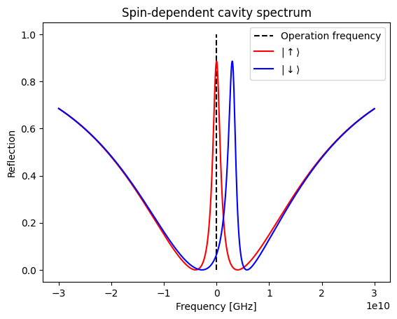

```python
fig, ax = plt.subplots()

ax.vlines(parameters["f_operation"], 0, 1, label = 'Operation frequency', color = 'k', linestyle='--')
ax.plot(frequencies, np.abs(r_up)**2, label = r"$|\uparrow\rangle$", color = 'r')
ax.plot(frequencies, np.abs(r_down)**2, label = r"$|\downarrow\rangle$", color = 'b')

ax.set_title('Spin-dependent cavity spectrum')
ax.set_xlabel('Frequency [GHz]')
ax.set_ylabel('Reflection')
plt.legend()
```

This deviates from the ideal case, as at the operation frequency the reflectivity for spin up is not perfectly 1 and for spin down is not perfectly zero. Indeed we are interested in what fidelity we can achieve with this configuration.

First, we need to change the SPI LBB:

```python
def conditional_amplitude_reflection_time_bin_spi(
    dm_in,
    spin_name,
    photon_early_name,
    photon_late_name,
    dim,
    atom_centered=True,
    f_operation=None,
    kappa_r=None,
    kappa_t=None,
    kappa_loss=0,
    gamma=None,
    delta=None,
    splitting=None,
    g=None,
    ideal=False,
    gamma_dephasing=0,
    **kw,
):

    #We just chhange how we get the reflection coefficients, which now are taken from the quantum optical modeling
    C = 4 * g**2 / (kappa_t + kappa_r + kappa_loss) / (gamma + gamma_dephasing)

    t_u, r_u, l_u = qom.cavity_qom_cavity_centered(
                f_operation, delta, kappa_r, kappa_t, kappa_loss, gamma, C, gamma_dephasing=gamma_dephasing
            )
    t_d, r_d, l_d = qom.cavity_qom_cavity_centered(
                f_operation, delta - splitting, kappa_r, kappa_t, kappa_loss, gamma, C, gamma_dephasing=gamma_dephasing
            )


    # We provide the parameters to the Physical Building Block of a conditional amplitude reflection SPI
    cav = pbb.conditional_amplitude_reflection(r_u, t_u, l_u, r_d, t_d, l_d, dim=dim)

    # Specifying which Spin it refers to.
    cav.rename("spin", spin_name)

    # We realise PBB implementation of the LBB, first the cavity is applied to Early
    cav.rename("R", photon_early_name)
    cav.rename("T", "loss_transmission")
    cav.rename("loss", "loss")

    dm_E_full = cav * dm_in * cav.dag()

    # Tracing out the lost modes
    dm_E = lbb.trace_out_loss_modes(dm_E_full)

    # We apply a pi rotation on the spin
    RX_pi = nq.NQobj([[0, 1], [1, 0]], names=spin_name, kind="oper")

    # And we apply the same cavity PBB to Late by renaming the photonic mode it operates on
    cav.rename(photon_early_name, photon_late_name)
    dm_L_full = cav * (RX_pi * dm_E * RX_pi.dag()) * cav.dag()

    #Finally we trace out the lost modes.
    dm_L = lbb.trace_out_loss_modes(dm_L_full)

    #Finally, we return the modified density matrix
    return dm_L
```

We can the redefine the protocol:

```python
class ExampleProtocol(Protocol):
    """
        Our protocol class to simulate Spin-Photon Entanglement
    """
    def __init__(self, parameters: dict):
        super().__init__(parameters)

        # We prepare the initial state of the spins in |x >
        self.dm_init = nq.tensor(nq.name(st.x_dm, "Alice", "state"), nq.name(st.x_dm, "Bob", "state"))

        # We definet the two herald state projectors.
        self.herald_projectors = [
            no_vacuum_projector(name="E", dim=self.dim),
            no_vacuum_projector(name="L", dim=self.dim),
        ]

        # And the corresponding target entangled states

        state_uu = nq.tensor(nq.name(st.up, "Alice", "state"), nq.name(st.up, "Bob", "state"))
        state_dd = nq.tensor(nq.name(st.down, "Alice", "state"), nq.name(st.down, "Bob", "state"))

        self.target_states = [
            (state_uu + state_dd).unit(),
            (state_uu - state_dd).unit()
        ]


    def protocol_sequence(self):
        self.do_lbb(lbb.photon_source_time_bin, photon_early_name="E", photon_late_name="L")

        self.do_lbb(
            conditional_amplitude_reflection_time_bin_spi,
            photon_early_name="E",
            photon_late_name="L",
            spin_name="Alice",
        )

        self.do_lbb(
            conditional_amplitude_reflection_time_bin_spi,
            photon_early_name="E",
            photon_late_name="L",
            spin_name="Bob",
        )

        self.do_lbb(lbb.basis_rotation, photon_names=["E", "L"])
```

And we run it with the same parameters we have shown before

```python
p = ExampleProtocol(parameters)
p.run()

print( f"The Fidelities for the two herald states are: [{p.fidelity[0]:.3f}, {p.fidelity[1]:.3f}] and the Success Probability: [{p.rate[0]:.3f}, {p.rate[1]:.3f}] ")
```

```
The Fidelities for the two herald states are: [0.747, 1.000] and the Success Probability: [0.115, 0.111]
```

The protocol was successful, as we can see one of the two states has higher fidelity than the other (this is expected when the two nodes have equal parameters because the errors on $|\psi_-\rangle$ cancel out [2]).

The total fidelity and rate the protocol calculates is the weighted average over the success probability of the two fidelities)

```python
print(f"Total fidelity: {p.fidelity_total:.3f}, total Success Probability: {p.rate_total:.3f}")
```

```
Total fidelity: 0.871, total Success Probability: 0.226
```

### References

[1] H.K.C. Beukers, M. Pasini, H. Choi et. al., (2023) 'Tutorial: Remote entanglement protocols for stationary qubits with photonic interface', link

[2] C.M. Knaut, A. Suleymanzade, Y.-C. Wei, D. R. Assumpcao, P.-J. Stas et al. (2023) ‘Entanglement of Nanophotonic Quantum Memory Nodes in a Telecommunication Network’. arXiv. Available at: https://doi.org/10.48550/arXiv.2310.01316.